# Ecce Signum: Illustration

# New Zealand Arrivals

## Loading Packages

This code loads the data into a variable named **imm**.

```r
## wipe
rm(list=ls())
library(devtools)
```

```
## Error in get(genname, envir = envir) : object 'testthat_print' not found
```

```r
library(Rcpp)

load_all(".")
```

```
## Loading sigex
```

```r
root.dir <- getwd()
```

- We do some initial processing.
- The original data is grouped into “months” of 31 days, with extra days of value zero added for months of shorter length; our code removes these features, as well as a monthly summation.

```r
n.months <- dim(imm)[1]/32
imm <- imm[-seq(1,n.months)*32,]
imm <- matrix(imm[imm != 0],ncol=6)
```

- Also we load a set of regressors that will be used in later analysis.
- The first column is a regressor that captures a moving holiday effect for Easter, and the next six columns correspond to school holidays for public schools in New Zealand: an effect is estimated for the start and end of the holiday for the first three school vacations in each year. The last three columns correspond to Y2K effects (but will not be used in this script).

```r
NZregs <- read.table(paste(root.dir,"/data/NZregressors.txt",sep=""))
```

## Enter Metadata

- We perform an analysis of one series by using an embedding to the weekly frequency.
- First enter metadata, including starting date and frequency.

```r
start.date <- c(9,1,1997)
end.date <- day2date(dim(imm)[1]-1,start.date)
period <- 365
```

- Next we do some calendar calculations.

```r
start.day <- date2day(start.date[1],start.date[2],start.date[3])
end.day <- date2day(end.date[1],end.date[2],end.date[3])
begin <- c(start.date[3],start.day)
end <- c(end.date[3],end.day)
```

- Finally, there is a call to **sigex.load**, which associates labels to the data.
- The last argument of **sigex.load** generates a time series plot.

```r
dataALL.ts <- sigex.load(imm,begin,period,
                         c("NZArr","NZDep","VisArr","VisDep","PLTArr","PLTDep"),TRUE)
```

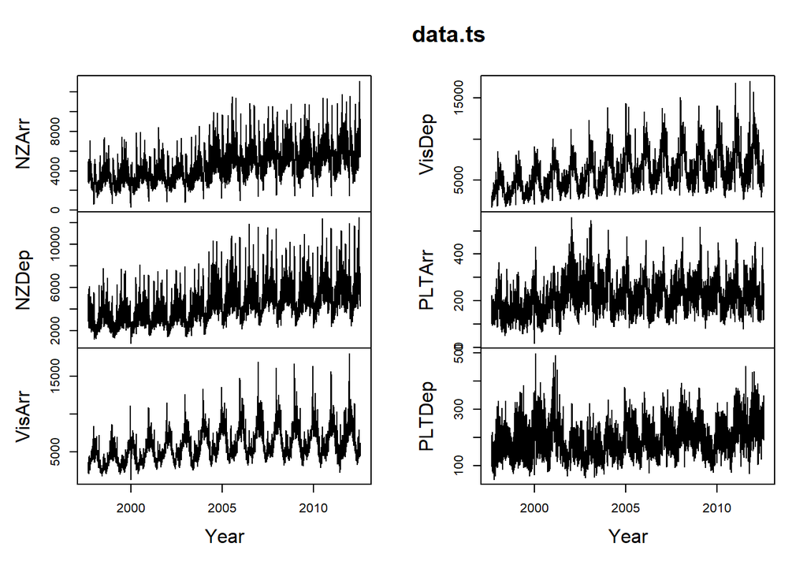

## Select Spans and Transforms

- On the basis of the above plot, we decide to utilize a log transformation for the data.
- The *aggregate* option will sum across the indicated series, in case we want to analyze an aggregate. Here we set it to FALSE.
- We can also select a subcomponent of series with *subseries*. Here we focus on the first series only.
- The *range* argument of **sigex.prep** will select a subset of dates for the time series to be analyzed.

```r
transform <- "log"
aggregate <- FALSE
subseries <- 1
range <- list(c(2008,1),end)
dataONE.ts <- sigex.prep(dataALL.ts,transform,aggregate,subseries,range,TRUE)
```

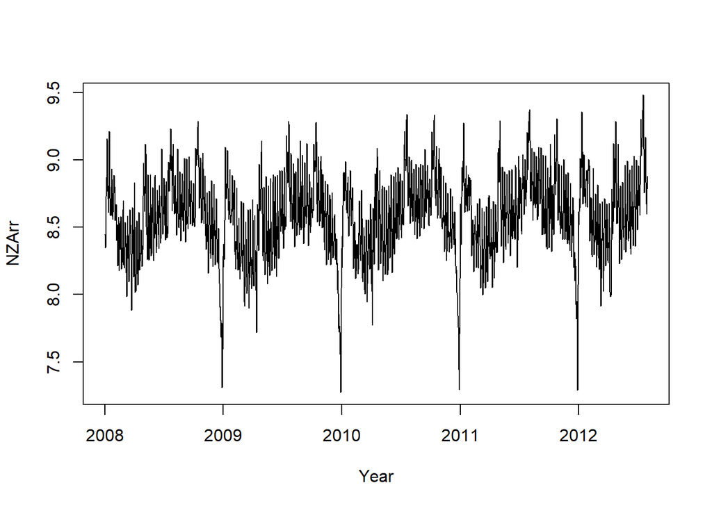

## Spectral Exploratory Analysis

- In order to get an idea about model specification, we can examine spectral estimates, using **sigex.specar**.
- We can look at raw data or differenced data (growth rates).

```r
par(mfrow=c(1,1))
for(i in 1:length(subseries))
{
  sigex.specar(dataONE.ts,FALSE,i,7)
}
```

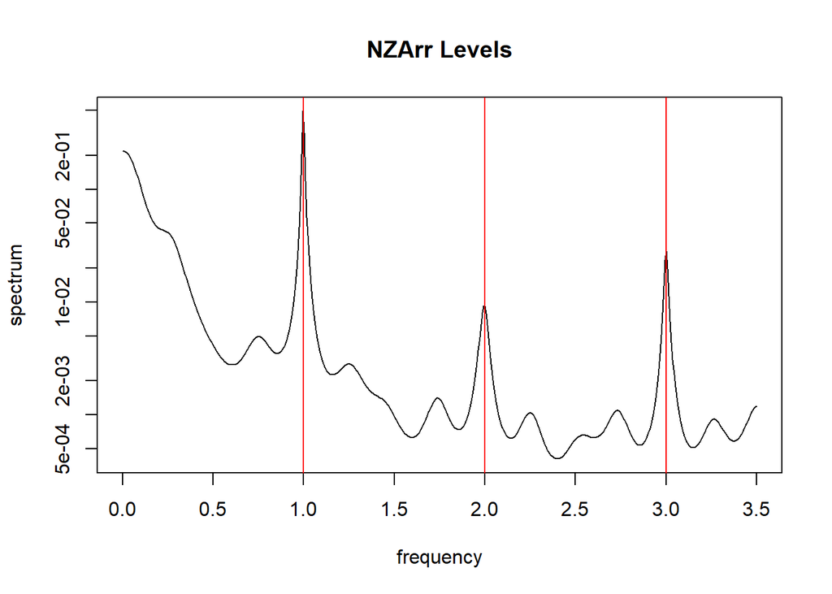

```r
dev.off()
```

```r
par(mfrow=c(1,1))
for(i in 1:length(subseries))
{
  sigex.specar(dataONE.ts,TRUE,i,7)
}
```

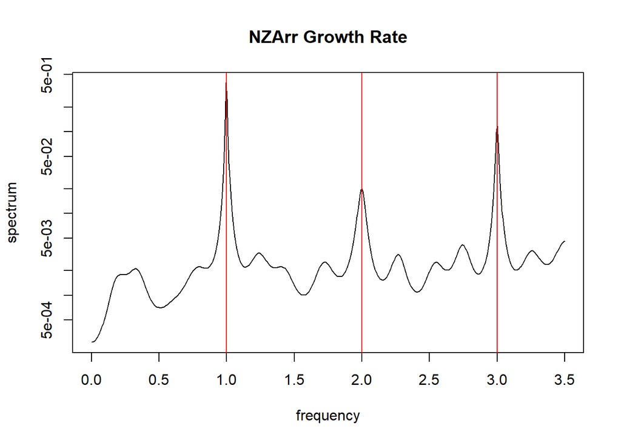

```r
dev.off()
```

## Embed to Weekly

- We set the first day of the week to be Sunday, and embed the time series as a $7$-variate weekly time series via a call to **sigex.daily2weekly**.

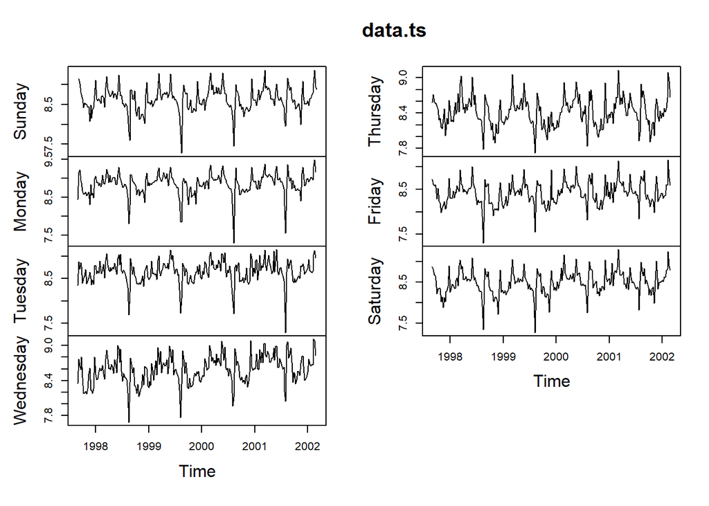

```r
first.day <- 1
data.ts <- sigex.daily2weekly(dataONE.ts,first.day,start.date)
plot(data.ts)
```

## Model Declaration

- Now we want to define our time series model.
- We begin by defining dimension $N$ and sample size $T$.
- Note that although the data analyzed is univariate, because of the embedding now $N=7$.

```r
N <- dim(data.ts)[2]
T <- dim(data.ts)[1]
```

- Next, we define appropriate subspans of the holiday regressors.
- The *easter* regressor is based on the Easter day itself and also the day before Easter.
- The *school1* regressor corresponds to the beginning of the first school holiday, with a window for the day of and the day after.
- The *school2* and *school3* regressors are analogous for the 2nd and 3rd holidays.
- The *school1e* regressor corresponds to the end of the first school holiday, with a window for the day of and the day before.
- The *school2e* and *school3e* regressors are analogous for the 2nd and 3rd holidays.

```r
times <- seq((range[[1]][1]-begin[1])*period+(range[[1]][2]-begin[2])+1,
             (range[[2]][1]-begin[1])*period+(range[[2]][2]-begin[2])+1,1)
easter.reg <- NZregs[times,1]
school1.reg <- NZregs[times,2]
school1e.reg <- NZregs[times,3]
school2.reg <- NZregs[times,4]
school2e.reg <- NZregs[times,5]
school3.reg <- NZregs[times,6]
school3e.reg <- NZregs[times,7]
```

- These are the regressors for daily data, and need to be embedded as weekly series.

```r
easter.reg <- sigex.daily2weekly(easter.reg,first.day,start.date)
school1.reg <- sigex.daily2weekly(school1.reg,first.day,start.date)
school1e.reg <- sigex.daily2weekly(school1e.reg,first.day,start.date)
school2.reg <- sigex.daily2weekly(school2.reg,first.day,start.date)
school2e.reg <- sigex.daily2weekly(school2e.reg,first.day,start.date)
school3.reg <- sigex.daily2weekly(school3.reg,first.day,start.date)
school3e.reg <- sigex.daily2weekly(school3e.reg,first.day,start.date)
```

- Next, we replace any ragged edge NA values (arising from embedding) with zero, which is appropriate because the corresponding data values are also missing.

```r
easter.reg[is.na(easter.reg)] <- 0
school1.reg[is.na(school1.reg)] <- 0
school1e.reg[is.na(school1e.reg)] <- 0
school2.reg[is.na(school2.reg)] <- 0
school2e.reg[is.na(school2e.reg)] <- 0
school3.reg[is.na(school3.reg)] <- 0
school3e.reg[is.na(school3e.reg)] <- 0
```

## Model Specification

- The data has a slight upwards trend drift, and there is strong annual correlation present.
- We will fit a SVARMA model for data differenced to stationarity by applying annual differencing $1 - L^{52}$. (Here $L$ is the weekly lag operator, and there are approximately 52 weeks per year.)
- We set the model order to a nonseasonal $q=1$ and seasonal $P = 1$.

```r
mdl <- NULL
mdl <- sigex.add(mdl,seq(1,N),"svarma",c(0,1,1,0,52),NULL,"process",c(1,rep(0,51),-1))
mdl <- sigex.meaninit(mdl,data.ts,0)
```

- The call to **sigex.add** indicates there is one main component.
- The second argument indicates the rank configuration for the process; setting *vrank* equal to seq(1,N) ensures a full rank covariance matrix.
- The third argument gives the model type as *svarma*;  
  the order $q=1$, $P=1$ of the SVARMA is given in the fourth argument.
- The fifth argument provides parameter bounds, and does not apply to this type of model, and hence is set to NULL.
- The sixth argument associates a label.
- The last argument is for the scalar differencing operator $\delta^{(1)} (z)$, expressed as a vector of coefficients.
- The specification of the regressors takes more coding, as we loop over the days of the week.

```r
for(i in 1:N) {
  mdl <- sigex.reg(mdl,i,ts(as.matrix(easter.reg[,i]),
                            start=start(easter.reg),
                            frequency=frequency(easter.reg),
                            names="Easter-day"))
  mdl <- sigex.reg(mdl,i,ts(as.matrix(school1.reg[,i]),
                            start=start(school1.reg),
                            frequency=frequency(school1.reg),
                            names="School1-Start"))
  mdl <- sigex.reg(mdl,i,ts(as.matrix(school1e.reg[,i]),
                            start=start(school1e.reg),
                            frequency=frequency(school1e.reg),
                            names="School1-End"))
  mdl <- sigex.reg(mdl,i,ts(as.matrix(school2.reg[,i]),
                            start=start(school2.reg),
                            frequency=frequency(school2.reg),
                            names="School2-Start"))
  mdl <- sigex.reg(mdl,i,ts(as.matrix(school2e.reg[,i]),
                            start=start(school2e.reg),
                            frequency=frequency(school2e.reg),
                            names="School2-End"))
  mdl <- sigex.reg(mdl,i,ts(as.matrix(school3.reg[,i]),
                            start=start(school3.reg),
                            frequency=frequency(school3.reg),
                            names="School3-Start"))
  mdl <- sigex.reg(mdl,i,ts(as.matrix(school3e.reg[,i]),
                            start=start(school3e.reg),
                            frequency=frequency(school3e.reg),
                            names="School3-End"))
}
```

## Model Estimation

- Next we consider model fitting.
- Here we make use of parameter constraints for the regressors: because the same holiday effect is present for each day of the week (recall that the weekly regressors are derived from a single daily regressor), the parameter estimates should be constrained to be identical.
- We use the **sigex.constrainreg** function to do this: the *regindex* argument specifies indices $J_1, J_2, \ldots, J_N$ that delineate which regressors are being considered for each series.
- For instance, $J_1 = \{ 1, 3, 4 \}$ would correspond to the *trend*, *school1*, and *school1e* regressors for the first (Sunday) series.
- The *combos* argument provides the linear combinations of these regressors, but when set to NULL instead it is enforced that all the regression parameters are the same.

```r
constraint <- NULL
constraint <- rbind(constraint,sigex.constrainreg(mdl,data.ts,list(2,2,2,2,2,2,2),NULL))
constraint <- rbind(constraint,sigex.constrainreg(mdl,data.ts,list(3,3,3,3,3,3,3),NULL))
constraint <- rbind(constraint,sigex.constrainreg(mdl,data.ts,list(4,4,4,4,4,4,4),NULL))
constraint <- rbind(constraint,sigex.constrainreg(mdl,data.ts,list(5,5,5,5,5,5,5),NULL))
constraint <- rbind(constraint,sigex.constrainreg(mdl,data.ts,list(6,6,6,6,6,6,6),NULL))
constraint <- rbind(constraint,sigex.constrainreg(mdl,data.ts,list(7,7,7,7,7,7,7),NULL))
```

- So the first call here identifies in *regindex* the *easter* regressor for each of the seven series, and *combos* set to NULL indicates that these parameters will be equal.
- The next call does the same for the *school1* regressor, and so forth; the first regressor is the *trend*, and this remains unconstrained.
- The output of **sigex.constrainreg** is a *constraint* matrix, which can be then passed into the MLE fitting routine.

```r
par.mle <- sigex.default(mdl,data.ts,constraint)
psi.mle <- sigex.par2psi(par.mle,mdl)
```

- Having initialized the pre-parameter vector, we can start nonlinear optimization.
- In this case the nonlinear optimization can take a long time. So we just read the final MLE for *psi* in below.

```r
psi.mle <- c(0.195543136661102, 0.210896311604314, 0.224884839193806, 0.297710366252992,
             0.318076964322756, 0.288167112704856, 0.130848490409544, 0.17299456406149,
             0.213720675984967, 0.0780486278573135, 0.188624612762698, 0.467926733192453,
             0.434759495960342, 0.314822770386916, 0.280937951321511, 0.484722644882768,
             0.413444260303994, 0.193778981158949, 0.550345260075344, 0.621238984502903,
             0.563243057038342, -3.99208014979805, -4.19642305454813, -3.8415818035668,
             -4.32856255035426, -3.95499509133263, -3.96279211490641, -4.03911188215587,
             -0.369778097197869, -0.0318374973193093, -0.0459307709775452,
             -0.138903858423006, -0.10135335156786, -0.2142068950075, -0.112796685064521,
             -0.140796608637905, -0.237750837664742, -0.194243215055276, 0.0219933280900727,
             -0.0185736546749142, 0.139055815995136, 0.185830059881372, 0.0297317536468041,
             -0.0155812148508496, -0.0671396386183212, 0.0476284405203113,
             -0.0570660189385589, -0.155367001953893, -0.198330717820409,
             -0.0295063266207021, -0.073765478114995, -0.0829227752708303,
             -0.187804918878073, -0.0422869655675992, -0.0251387557650662,
             0.0656914410289482, -0.0840920843255883, -0.145935243196311,
             -0.0687523983229335, -0.117014892923535, -0.144653364980642,
             -0.0790943505687107, 0.0611829711400193, -0.104109662533708,
             0.112359996172669, -0.124553026055195, -0.163431409482439, -0.0283323592215797,
             -0.0312605011210402, -0.178946106450384, -0.266581746889425,
             -0.164720047360709, 0.00959770743708815, 0.159928359498417, -0.0132411806278071,
             -0.0642101491748187, -0.143487318464752, -0.086691994085389,
             0.0814467471639927, -0.0123455935133012, 0.00908782055333108,
             -0.0441428053848971, -0.0194126102991047, -0.00524075702955244,
             -0.0105279430631441, -0.00420628604690744, 0.0789699162821441,
             -0.015850906929479, -0.043499933859938, -0.0062803013365077,
             -0.0207414587537556, -0.0459309858718756, 0.0445914128582114,
             -0.0946876132299148, 0.00588335338136514, 0.00922656520387984,
             -0.0140866870525241, -0.0157842160720905, -0.0319375488373468,
             0.0514126088016708, 0.0141484170525309, -0.124101882618575, -0.00774709495827467,
             0.0255995670388491, -0.0364850207049338, 0.0230572817360244,
             0.0220446070005591, -0.000478476269822034, -0.0168616246820038,
             -0.102427194747844, 0.00112763406309242, -0.0259316390382219,
             -0.010758329862067, -0.00198961225224573, -0.0464823007621206,
             -0.0165414789720724, 0.0104091697972505, -0.14827440476309, 0.0505648610397286,
             -0.0183900737977979, 0.0311301005304512, 0.00518380184796121,
             0.0104592851480601, -0.0109208667318225, -0.0637859237889965,
             -0.0656126331052389, 0.00033010004554818, -0.191533893764455,
             -0.157111537080312, 0.141669136870683, -0.0225792281088362, 0.157100658532765,
             -0.08441684545665, 0.1847632577291, 0.000561604448005, -0.191533893764455,
             -0.157111537080311, 0.141669136870683, -0.0225792281088361, 0.157100658532765,
             -0.0844168454566499, 0.183411740706148, 0.000312708939566006,
             -0.191533893764455, -0.157111537080312, 0.141669136870683, -0.0225792281088362,
             0.157100658532765, -0.08441684545665, -0.00163601810705088, 0.00100594355939265,
             -0.191533893764455, -0.157111537080311, 0.141669136870683, -0.0225792281088362,
             0.157100658532765, -0.08441684545665, 0.0156601320968592, 9.68417444876468e-05,
             -0.191533893764455, -0.157111537080312, 0.141669136870683, -0.0225792281088361,
             0.157100658532765, -0.08441684545665, 0.00328023110252021, 0.000461006050610564,
             -0.191533893764455, -0.157111537080312, 0.141669136870683, -0.0225792281088361,
             0.157100658532765, -0.08441684545665, 0.00430421751741802, 0.000496876409071807,
             -0.191533893764455, -0.157111537080311, 0.141669136870683, -0.0225792281088362,
             0.157100658532765, -0.08441684545665, 0.0023532873975757)
par.mle <- sigex.psi2par(psi.mle,mdl,data.ts)
```

- We obtain, format, and store the residuals.
- Then we compute the autocorrelations, and plot.

```r
resid.mle <- sigex.resid(psi.mle,mdl,data.ts)[[1]]
resid.mle <- sigex.load(t(resid.mle),start(data.ts),frequency(data.ts),colnames(data.ts),TRUE)
```

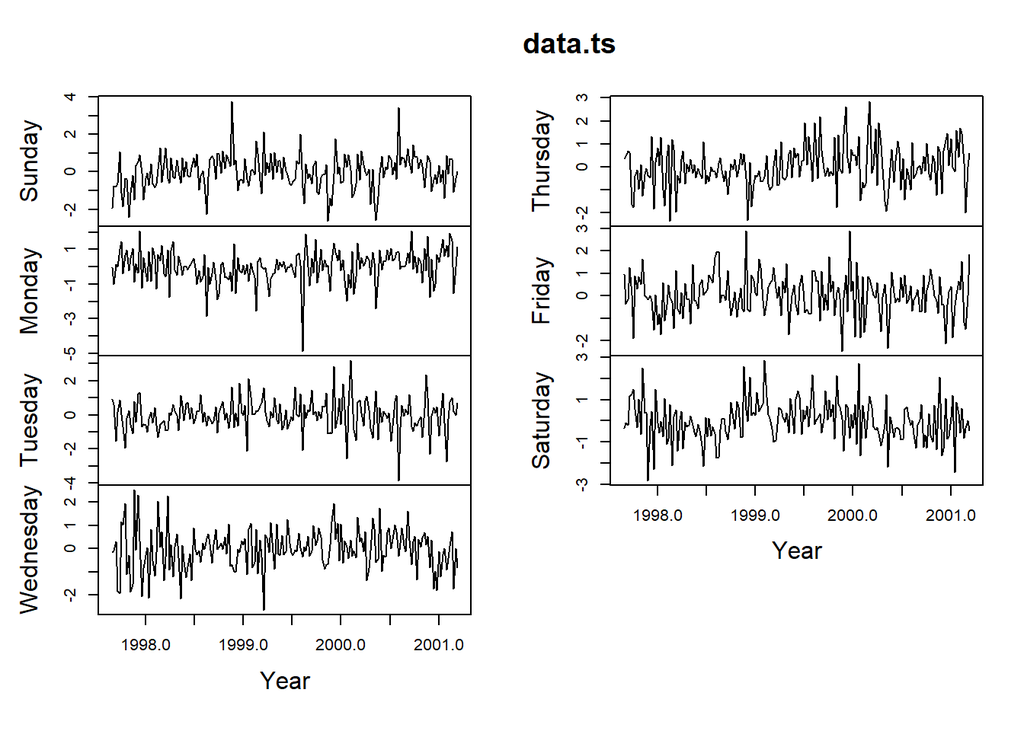

[figure not shown]

```r
resid.acf <- acf(resid.mle,lag.max=4*53,plot=FALSE)$acf
par(mfrow=c(N,N),mar=c(3,2,2,0)+0.1,cex.lab=.8,cex.axis=.5,bty="n")
for(j in 1:N)
{
  for(k in 1:N)
  {
    plot.ts(resid.acf[,j,k],ylab="",xlab="Lag",ylim=c(-1,1),cex=.5)
    abline(h=1.96/sqrt(T),lty=3)
    abline(h=-1.96/sqrt(T),lty=3)
  }
}
```

```r
dev.off()
```

- We can also examine the condition numbers, to see if there is rank reduction possible.
- Typically there won’t be any rank reduction with a single component model.

```r
log(sigex.conditions(data.ts,psi.mle,mdl))
```

```
##      [,1]        [,2]        [,3]       [,4]       [,5]      [,6]       [,7]
## eta2    0 -0.04583933 -0.04904707 -0.3793162 -0.4019348 -0.493954 -0.6951072
```

- We can examine the Portmanteau statistic for residual serial correlation.
- We use 2 years of lags.

```r
sigex.portmanteau(resid.mle,2*52,length(psi.mle))
```

```
## [1] 4178.816    1.000
```

```r
sigex.gausscheck(resid.mle)
```

```
## [1] 3.526846e-04 9.642205e-06 2.898214e-03 1.506332e-01 2.484404e-01
## [6] 2.753040e-01 1.364144e-01
```

- Having completed our model analysis, we store our results in a single list object.

```r
analysis.mle <- sigex.bundle(data.ts,transform,mdl,psi.mle)
```

## Signal Extraction

- Now we consider applying a daily seasonal adjustment filter that we embed as a $7$-variate weekly filter.
- First we load up the fitted model for signal extraction.

```r
data.ts <- analysis.mle[[1]]
mdl <- analysis.mle[[3]]
psi <- analysis.mle[[4]]
param <- sigex.psi2par(psi,mdl,data.ts)
```

- The daily seasonal adjustment filter *sa.hifilter* is an extension of the classic crude trend filter of X11 from monthly to daily frequency.
- It should suppress all daily frequencies of the form $2\pi j/365$ for $1 \leq j \leq 183$, while also passes linear trends. This is embedded with a call to **sigex.hi2low**, where the high and low frequencies are indicated and the *shift.hi* parameter is $c = 183$, corresponding to a symmetric filter.
- The output is the $7$-variate weekly filter *sa.lowfilter*, with shift parameter $C = 27$ given by *shift.low*.

```r
sa.hifilter <- c(1,rep(2,365),1)/(2*365)
len <- 183
hi.freq <- 7
low.freq <- 1
shift.hi <- len
out <- sigex.hi2low(sa.hifilter,hi.freq,low.freq,shift.hi)
sa.lowfilter <- out[[1]]
shift.low <- out[[2]]
```

- This filter is applied using a standard call of **sigex.adhocextract**.
- This function automatically supplies missing value imputations for the ragged edges, and does forecast and aftcast extension for application of the filter. However, this should be transformed back to a daily series, so that we can view the daily series with its seasonal adjustment.
- The function **sigex.weekly2daily** transforms the series, using the indicated value of *first.day*.
- We repeat this for the lower and upper values of the confidence intervals.

```r
sa.low <- sigex.adhocextract(psi,mdl,data.ts,sa.lowfilter,shift.low,0,TRUE)
sa.hi.daily <- list()
sa.hi.daily[[1]] <- sigex.weekly2daily(ts(sa.low[[1]],start=start(dataONE.ts),
                                           frequency=frequency(dataONE.ts)),first.day)
sa.hi.daily[[2]] <- sigex.weekly2daily(ts(sa.low[[2]],start=start(dataONE.ts),
                                           frequency=frequency(dataONE.ts)),first.day)
sa.hi.daily[[3]] <- sigex.weekly2daily(ts(sa.low[[3]],start=start(dataONE.ts),
                                           frequency=frequency(dataONE.ts)),first.day)
```

- For comparison we can design another filter that only removes the weekly dynamics.
- This is done by considering a simple filter annihilating weekly effects from the daily data, namely $(1 + B + \ldots + B^6)/7$, which we call the Trading Day (TD) filter.

```r
td.hifilter <- rep(1,7)/7
len <- 3
hi.freq <- 7
low.freq <- 1
shift.hi <- len
out <- sigex.hi2low(td.hifilter,hi.freq,low.freq,shift.hi)
td.lowfilter <- out[[1]]
shift.low <- out[[2]]
```

- Now $c = 3$ and $C = 1$ for the TD filter.

```r
td.low <- sigex.adhocextract(psi,mdl,data.ts,td.lowfilter,shift.low,0,TRUE)
td.hi.daily <- list()
td.hi.daily[[1]] <- sigex.weekly2daily(ts(td.low[[1]],start=start(dataONE.ts),
                                           frequency=frequency(dataONE.ts)),first.day)
td.hi.daily[[2]] <- sigex.weekly2daily(ts(td.low[[2]],start=start(dataONE.ts),
                                           frequency=frequency(dataONE.ts)),first.day)
td.hi.daily[[3]] <- sigex.weekly2daily(ts(td.low[[3]],start=start(dataONE.ts),
                                           frequency=frequency(dataONE.ts)),first.day)
```

- Before plotting, the trend must be computed.
- A subtlety is that we have $7$ trends, one for each day of week, which therefore combine long-term trend effects and day-of-week effects. The mean of the $7$ parameter values corresponds to the overall mean of each week, and the residual is the day-of-week effect in excess of the mean.
- First *reg.td* is computed, which is the trend means for each day-of-week expressed as a daily time series. We augment by one prior week’s values, which would be all zero, and then convert to a daily series.
- Next, *reg.trend* is obtained by filtering with $(1 + B + \ldots + B^6)/7$, and finally remove the NA value (resulting from using **filter**, which does not extend the input series).

```r
reg.td <- NULL
for(i in 1:N)
{
  reg.td <- cbind(reg.td,sigex.fixed(data.ts,mdl,i,param,"Trend"))
}
reg.td <- rbind(rep(0,N),reg.td)
reg.td <- ts(sigex.weekly2daily(reg.td,first.day),
                start=start(dataONE.ts),frequency=period)
reg.trend <- filter(reg.td,td.hifilter,method="convolution",sides=1)
reg.trend <- as.matrix(reg.trend[8:length(reg.td)])
```

- The illustration is completed with a display: the seasonal adjustment contains some mild weekly effects (because the filter is designed to remove daily, and not weekly frequencies), whereas the TD-adjusted component has annual movements but not weekly effects.

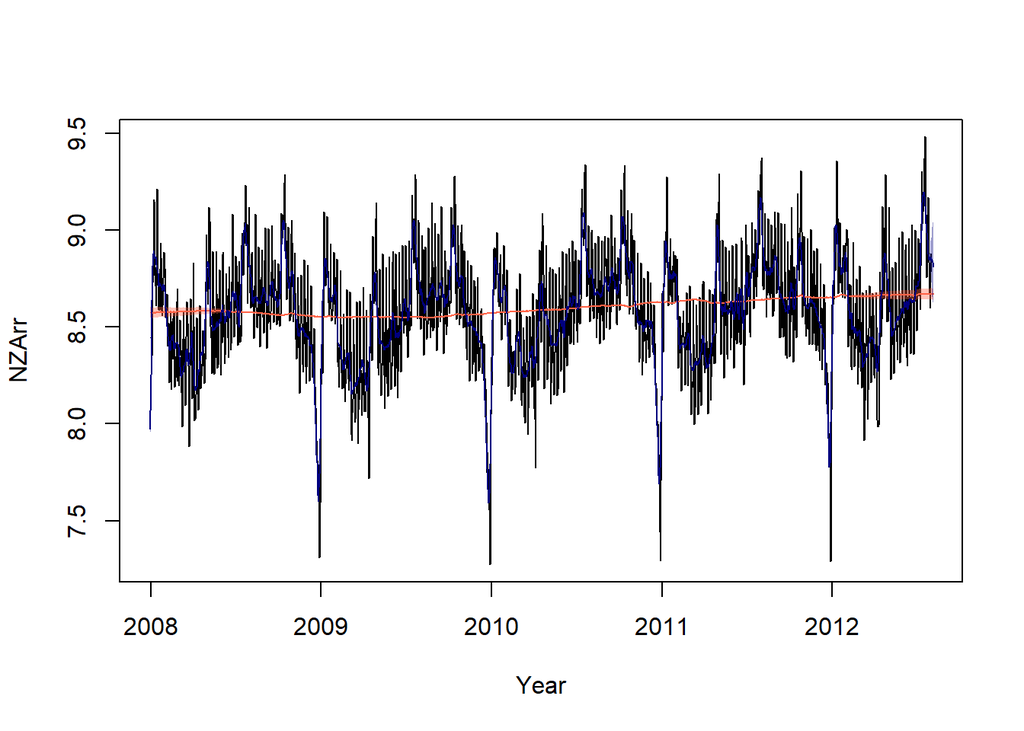

```r
trendcol <- "tomato"
cyccol <- "orchid"
seascol <- "seagreen"
sacol <- "navyblue"
fade <- 60
plot(dataONE.ts,xlab="Year")
sigex.graph(sa.hi.daily,reg.trend,start(sa.hi.daily[[1]]),
            period,1,0,trendcol,fade)
sigex.graph(td.hi.daily,reg.trend,start(td.hi.daily[[1]]),
            period,1,0,sacol,fade)
```

```r
dev.off()
```